# SBA Figure

Paul Testa and Jake Bowers

August 30, 2016

Document to create time series trend in SBA data

```r
# Load sba.cvs (saved locally) containing monthly estimates
sba <- read.csv("sba.csv", as.is = TRUE, strip.white = TRUE)
```

```r
# Rename date varialbe
print(sba$Date.Range)
```

```
 [1] "Sept 25 2014 - Oct 24 2014" "Oct 25 2014 - Nov 24 2014"  "Nov 25 2014 - Dec 24 2014"
 [4] "Dec 25 2014 - Jan 24 2015"  "Jan 25 2015 - Feb 24 2015"  "Feb 25 2015 - Mar 24 2015"
 [7] "Mar 25 2015 - Apr 21 2015"  "Apr 21 2015 - May 24 2015"  "May 24 2015 - July 24 2015"
[10] "Sept 25 2015 - Oct 24 2015" "Oct 25 2015 - Nov 24 2015"  "Nov 25 2015 - Dec 24 2015"
[13] "Dec 25 2015 - Jan 24 2016"  "Jan 25 2016 - Feb 24 2016"  "Feb 25 2016 - Mar 24 2016"
[16] "Mar 25 2016 - Apr 21 2016"  "Apr 21 2016 - May 24 2016"  "May 24 2016 - July 24 2016"
```

```r
sba$Date.Range[sba$Date.Range == "May 24 2016 - July 24 2015"] <- "May 24 2015 - July 24 2015"
sba$Date <- 1:nrow(sba)

sba$Dates <- gsub("[[:blank:]]*- [[:alnum:]]*[[:blank:]]*[[:alnum:]]*[[:blank:]]*[[:alnum:]]*[[:alnum:]]*[[:alnum:]]",
    "", sba$Date.Range)
sba$Dates <- gsub("Sept", "Sep", sba$Dates)
# sba$Dates<-factor(sba$Dates,levels=sba$Dates)
library(lubridate)
sba$DateStart <- mdy(as.character(sba$Dates))

tmp <- (1 - sba[, 4]/sba[, 3]) * 100
cbind(tmp, sba$Converstion.Rate.to.Course)
```

```
      tmp
 [1,] "49.9179120185224" "49.90%"
 [2,] "54.0916402885164" "54.10%"
 [3,] "54.0236124304519" "54.00%"
 [4,] "52.2967757998257" "52.30%"
 [5,] "52.5195844213567" "52.50%"
 [6,] "51.6946754936909" "51.70%"
 [7,] "51.7142152429499" "51.70%"
 [8,] "53.093864708967"  "53.10%"
 [9,] "54.2884523239099" "54.30%"
[10,] "56.3719208315535" "56.40%"
[11,] "55.1003082972164" "55.10%"
[12,] "57.8490997772024" "57.80%"
[13,] "56.5910402699463" "56.60%"
[14,] "58.9792198323004" "59.00%"
[15,] "57.252791245941"  "57.30%"
[16,] "64.7416272381483" "64.70%"
[17,] "63.7414426034329" "63.70%"
[18,] "63.6863692728371" "63.70%"
```

```r
names(sba)[5] <- "ConversionRate"
sba$ConversionRate <- (1 - sba[, 4]/sba[, 3]) * 100
class(sba[, "ConversionRate"])
```

```
[1] "numeric"
```

```r
sba$BeganCourse1000 <- sba[, 3]/1000

## Provided some information
names(sba)[names(sba) == "X..Completed.Some.Information"] <- "CompletedSomeInfo"
sba$SomeInfo <- with(sba, (Completed.Some.Information + Completed.All.Information)/(sba$Completed.Some.Information +
    sba$Completed.No.Information + sba$Completed.All.Information)) * 100

as.character(sba$Variation[1])
```

```
[1] "Old Form"
```

```r
## sba$Form<-ifelse(sba$Variation=='Old Form','Pre Change','Post Change')
sba$Form <- ifelse(sba$Variation != "Old Form", "New Form", as.character(sba$Variation))
```

Collapse the information about the new forms.

```r
newdat <- sba[, c("Date", "Dates", "ConversionRate", "SomeInfo", "Form")]

newdat[newdat$Dates %in% c("Mar 25 2016", "Apr 21 2016", "May 24 2016"), "Dates"] <- "Mar 24 to May 24 2016"

newdat$ConversionRate[newdat$Dates == "Mar 24 to May 24 2016"] <- mean(newdat$ConversionRate[newdat$Dates == "Mar 24 to May 24 2016"])

newdat$SomeInfo[newdat$Dates == "Mar 24 to May 24 2016"] <- mean(newdat$SomeInfo[newdat$Dates == "Mar 24 to May 24 2016"])

newdat <- newdat[1:16, ]
newdat$Dates <- factor(newdat$Dates, levels = newdat$Dates)
```

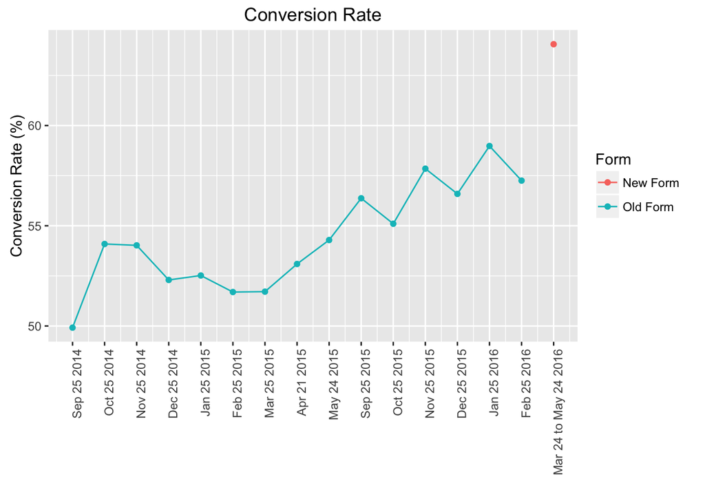

```r
p_sba_conv <- ggplot(newdat, aes(x = Date, y = ConversionRate, col = Form)) + geom_line() + geom_point() + scale_x_continuous(breaks = 1:16,
    labels = newdat$Dates) + theme(axis.text.x = element_text(angle = 90, hjust = 1)) + labs(y = "Conversion Rate (%)",
    x = "", title = "Conversion Rate")
p_sba_conv
```

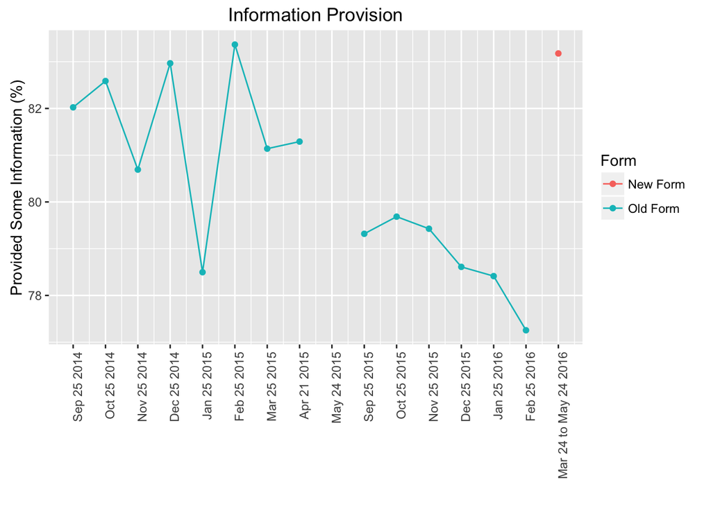

```r
p_sba_info <- ggplot(newdat, aes(x = Date, y = SomeInfo, col = Form)) + geom_line() + geom_point() + scale_x_continuous(breaks = 1:16,
    labels = newdat$Dates) + theme(axis.text.x = element_text(angle = 90, hjust = 1)) + labs(y = "Provided Some Information (%)",
    x = "", title = "Information Provision")
p_sba_info
```

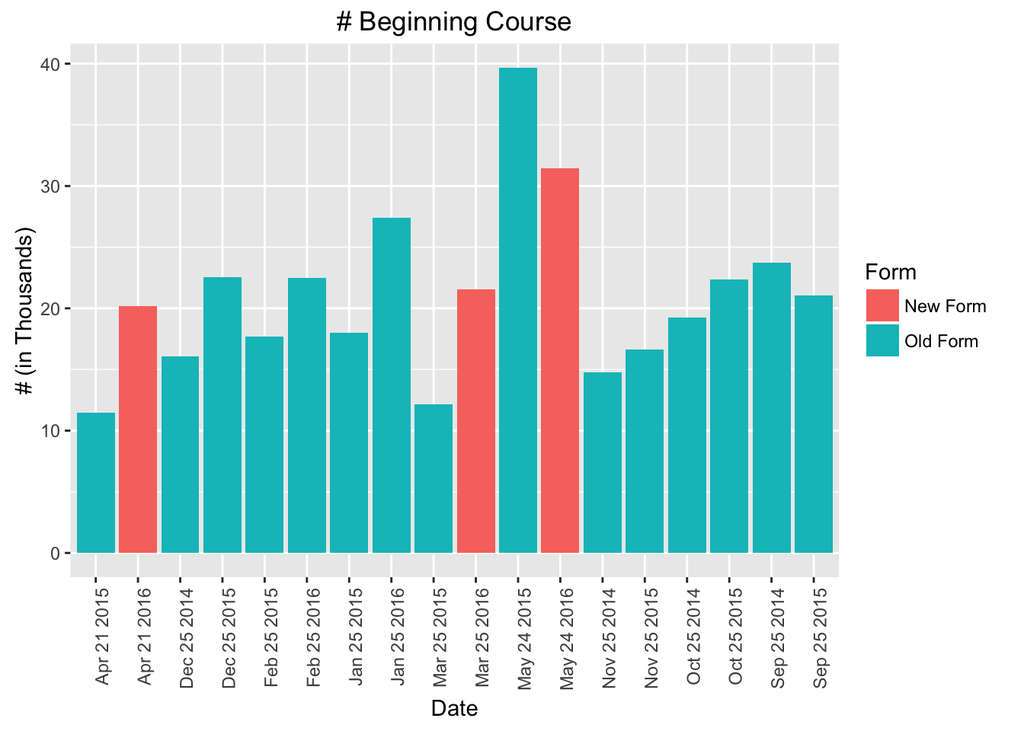

```r
p_sba_part <- ggplot(sba, aes(x = Dates, y = BeganCourse1000, fill = Form)) + geom_bar(stat = "identity") + theme(axis.text.x = element_text(angle = 90,
    hjust = 1)) + labs(y = "# (in Thousands)", x = "Date", title = "# Beginning Course")
p_sba_part
```

```r
# Slight edits to combine into one figure
p_sba_conv_c <- ggplot(sba, aes(x = Date, y = ConversionRate, col = Form)) + geom_line() + scale_x_continuous(breaks = 1:18,
    labels = sba$Dates) + theme(axis.ticks = element_blank(), axis.text.x = element_blank()) + labs(y = "Conversion Rate (%)",
    x = "", title = "Conversion Rate")

p_sba_part_c <- ggplot(sba, aes(x = Dates, y = BeganCourse1000, fill = Form)) + geom_bar(stat = "identity") + theme(axis.text.x = element_text(angle = 90,
    hjust = 1)) + labs(y = "# (in Thousands)", x = "Date", title = "# Beginning Course")
```

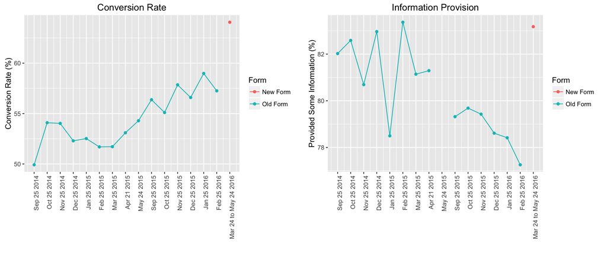

```r
grid.arrange(p_sba_conv, p_sba_info, ncol = 2)
```

# Test of Proprotions: Conversion Rate

Do a test of proportions (prop.test) converting during mar–may 2016 versus average of jan and feb 2016. Also test mar–may 2016 versus mar–may 2015.

```r
# Number converted
sba$Converted <- sba[, 3] - sba[, 4]
# Create table for prop test
contab1 <- matrix(NA, 2, 2)
rownames(contab1) <- c("Mar-May 2016", "Jan-Feb 2016")
colnames(contab1) <- c("Converted", "Not Converted")
# Add success and failures Post change
contab1[1, ] <- colSums(sba[sba$Dates %in% c("Mar 25 2016", "Apr 21 2016", "May 24 2016"), c(16, 4)])
# January to Febuary
contab1[2, ] <- colSums(sba[sba$Dates %in% c("Dec 25 2015", "Jan 25 2016", "Feb 25 2016"), c(16, 4)])
conprop1 <- prop.test(contab1)
conprop1
```

```
    2-sample test for equality of proportions with continuity correction

data:  contab1
X-squared = 610, df = 1, p-value <2e-16
alternative hypothesis: two.sided
95 percent confidence interval:
 0.05810 0.06813
sample estimates:
prop 1 prop 2
0.6401 0.5770
```

```r
#
contab2 <- matrix(NA, 2, 2)
rownames(contab2) <- c("Mar-May 2016", "Mar-May 2015")
colnames(contab2) <- c("Converted", "Not Converted")
# Add success and failures

contab2[1, ] <- colSums(sba[sba$Dates %in% c("Mar 25 2016", "Apr 21 2016", "May 24 2016"), c(16, 4)])
contab2[2, ] <- colSums(sba[sba$Dates %in% c("Mar 25 2015", "Apr 21 2015", "May 24 2015"), c(16, 4)])

conprop2 <- prop.test(contab2)
conprop2
```

```
    2-sample test for equality of proportions with continuity correction

data:  contab2
X-squared = 1500, df = 1, p-value <2e-16
alternative hypothesis: two.sided
95 percent confidence interval:
 0.09912 0.10958
sample estimates:
prop 1 prop 2
0.6401 0.5358
```

Compared to the proportion converting between January and February in 2016 (57.7 percent), the new forms increased conversion by 6.31 percent (p<0.001, 95% CI [5.81, 6.81])

# Test of Proportions: Some Information

```r
# Number converted
sba$SomeInfo_cnt <- sba$SomeInfo <- with(sba, Completed.Some.Information + Completed.All.Information)
sba$NoInfo_cnt <- sba$Completed.No.Information

# Create table for prop test
infotab1 <- matrix(NA, 2, 2)
rownames(infotab1) <- c("Mar-May 2016", "Dec 2015-Feb 2016")
colnames(infotab1) <- c("Some Info", "No Info")
# Add success and failures Post change
infotab1[1, ] <- colSums(sba[sba$Dates %in% c("Mar 25 2016", "Apr 21 2016", "May 24 2016"), c("SomeInfo_cnt", "NoInfo_cnt")])
# January to Febuary
infotab1[2, ] <- colSums(sba[sba$Dates %in% c("Dec 25 2015", "Jan 25 2016", "Feb 25 2016"), c("SomeInfo_cnt", "NoInfo_cnt")])
infoprop1 <- prop.test(infotab1)
infoprop1
```

```
    2-sample test for equality of proportions with continuity correction

data:  infotab1
X-squared = 610, df = 1, p-value <2e-16
alternative hypothesis: two.sided
95 percent confidence interval:
 0.05283 0.06200
sample estimates:
prop 1 prop 2
0.8384 0.7809
```

```r
#
infotab2 <- matrix(NA, 2, 2)
rownames(infotab2) <- c("Mar-May 2016", "Mar-May 2015")
colnames(infotab2) <- c("Converted", "Not Converted")
# Add success and failures

infotab2[1, ] <- colSums(sba[sba$Dates %in% c("Mar 25 2016", "Apr 21 2016", "May 24 2016"), c("SomeInfo_cnt", "NoInfo_cnt")])
infotab2[2, ] <- colSums(sba[sba$Dates %in% c("Mar 25 2015", "Apr 21 2015", "May 24 2015"), c("SomeInfo_cnt", "NoInfo_cnt")],
    na.rm = T)

infoprop2 <- prop.test(infotab2)
infoprop2
```

```
    2-sample test for equality of proportions with continuity correction

data:  infotab2
X-squared = 83, df = 1, p-value <2e-16
alternative hypothesis: two.sided
95 percent confidence interval:
 0.02043 0.03203
sample estimates:
prop 1 prop 2
0.8384 0.8121
```

Compared to the proportion providing some info between January and February in 2016 (78.09 percent), the new forms increased information provision by 5.74 percent (p<0.001, 95% CI [5.28, 6.2])